# Mapping Hong Kong public housing with API data collection

Po-Sheng Lee

Nov. 20, 2018

# Housing in Hong Kong

Among cities in the world, housing prices in Hong Kong ranked as the most expansive and unaffordable one. A citizen with median salary has to spend all her 18 years salary to buy a house in Hong Kong. The housing price is rampant despite a full-fledged public housing system.

This short report on public housing would take advantage of the API system built by Hong Kong government. I download the public housing data through API and do the geovisualized analysis.

## Mapping the property owned by the housing authority in Hong Kong.

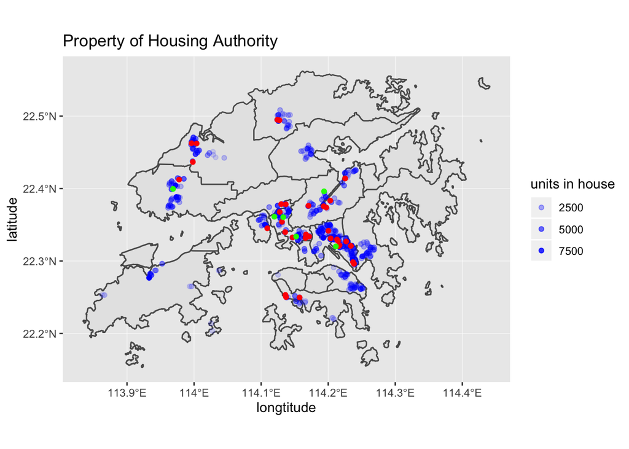

This map illustrate the properties owned by the housing authority. Red, green and blue dots denote shopping center, factory building and housing complexes seperately. The depth of the blue color illustrate the capacity of the housing complexes: the deeper the color means the more units one complex provides.

As the map illustrates, most shopping centers and housing complexes locate at the east side of Hong Kong Island and Kowloon pennisula, especailly Kwun Tong and Wong Tai Sing district. These are districts which used to be the industrial areas.

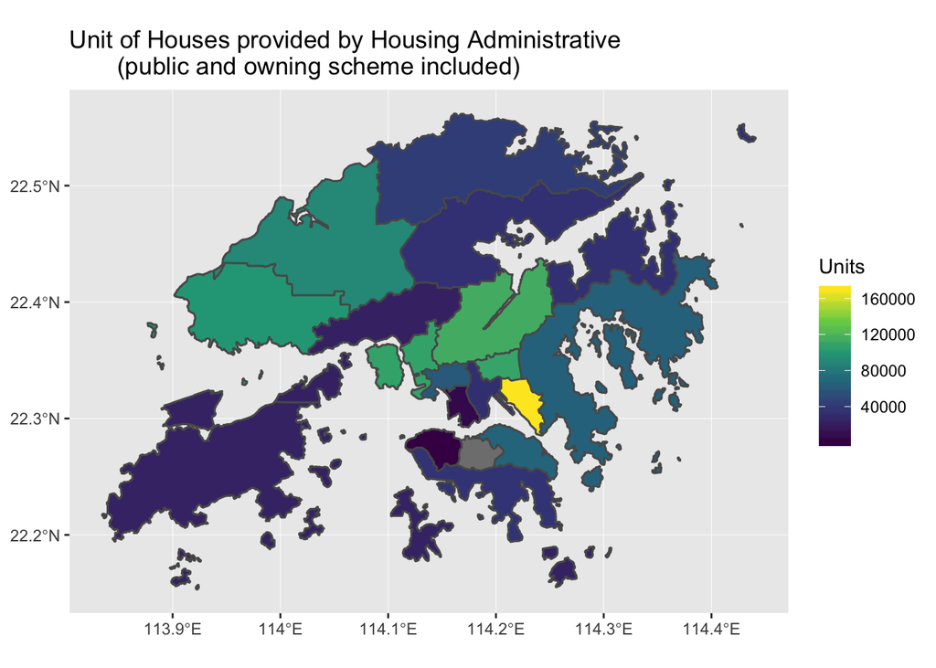

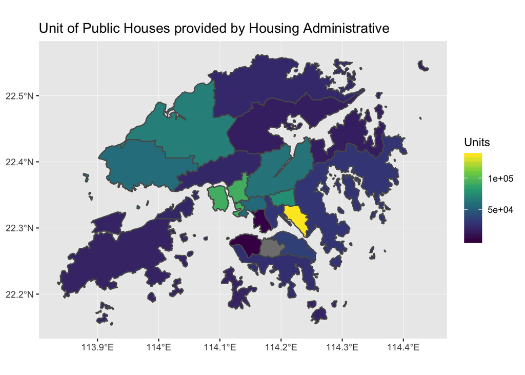

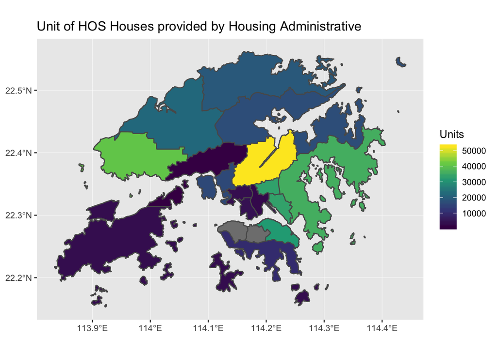

The three plots above show more clearly that the geographical distribution of public housing schemes. The first plot shows the total units of public housing in Hong Kong by districts. Most units are located in the East Kowloon and northwest of New Territory.

Public housing is comprised by two different types of housing projects: first is the public housing for rent and the second one is the buyable houses (Housing Ownership Scheme or HOS). The former is the public housing projects dated back to 1970’s and the later is designed to alleviate the grievances of SARS outbreak in 2003.